# Chapter 5 - Dimensionality reduction techniques

## Overview of the data

In this analysis we will be using data set called *“human”*, which is a combination of the following two data sets:

- [human development](http://s3.amazonaws.com/assets.datacamp.com/production/course_2218/datasets/human_development.csv)
- [gender inequality](http://s3.amazonaws.com/assets.datacamp.com/production/course_2218/datasets/gender_inequality.csv)

Meta file for these data sets can be found from [here](http://hdr.undp.org/en/content/human-development-index-hdi)

Let us look closer how does the data look like.

```r
date()
```

```
## [1] "Thu Dec 02 13:41:09 2021"
```

```r
human = read.table("http://s3.amazonaws.com/assets.datacamp.com/production/course_2218/datasets/human2.txt", sep=",", header=TRUE)

#Using my own table did not work for some reason
#human = read.table(file="human5.txt", sep=",", header=TRUE)

#Let us see the dimensions and structure of the data set
dim(human)
```

```
## [1] 155   8
```

```r
str(human)
```

```
## 'data.frame':    155 obs. of  8 variables:
##  $ Edu2.FM  : num  1.007 0.997 0.983 0.989 0.969 ...
##  $ Labo.FM  : num  0.891 0.819 0.825 0.884 0.829 ...
##  $ Edu.Exp  : num  17.5 20.2 15.8 18.7 17.9 16.5 18.6 16.5 15.9 19.2 ...
##  $ Life.Exp : num  81.6 82.4 83 80.2 81.6 80.9 80.9 79.1 82 81.8 ...
##  $ GNI      : int  64992 42261 56431 44025 45435 43919 39568 52947 42155 32689 ...
##  $ Mat.Mor  : int  4 6 6 5 6 7 9 28 11 8 ...
##  $ Ado.Birth: num  7.8 12.1 1.9 5.1 6.2 3.8 8.2 31 14.5 25.3 ...
##  $ Parli.F  : num  39.6 30.5 28.5 38 36.9 36.9 19.9 19.4 28.2 31.4 ...
```

There are 155 observations of 8 variables:

- *Edu2.FM “PSE_ratio”* > Ratio of Female and Male populations with secondary education in each country
- *Labo.FM “LFPR_ratio”* > Ratio of labour force participation of females and males in each country
- *Edu.Exp “EYE”* > Expected Years of Education
- *Life.Exp “LEB”* > Life Expectancy at Birth
- *GNI* > Gross National Income (GNI) per Capita
- *Mat.Mor “MMR”* > Maternal Mortality Ratio
- *Ado.Birth “ABR”* > Adolescent Birth Rate
- *Parli.F “PRP”* > Percent Representation in Parliament

Let us next show a graphical overview of the data:

```r
library(GGally)
library(dplyr)
```

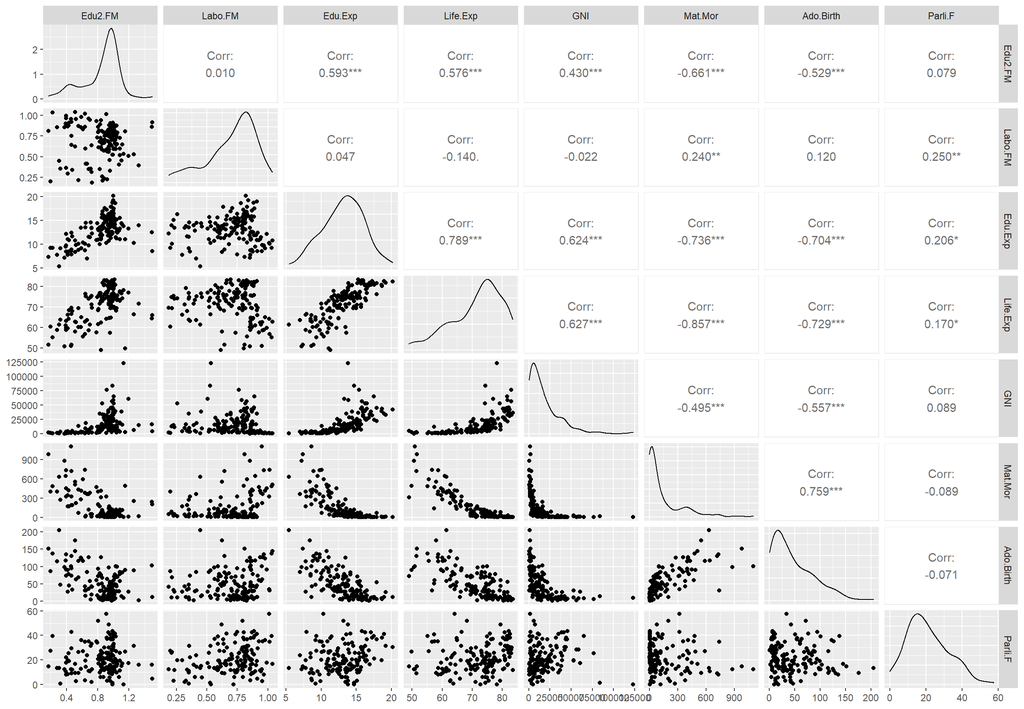

```r
library(corrplot)
#Visualizing the 'human' variables
ggpairs(human)
```

Above we have used a generalized pairs plot from the GGally package to visualize the data frame.

From the **distributions** of the variables we can say, that the *expected years of life* and *education* are both relatively **high**. The *ratio of labour force participation of females* and *males in each country* shows also a relatively high peak. In turn, the amount of *GNI, maternal mortality* and *adolesent birth rate* are relatively **low**. Also the *percent representation of females in parliament* is quite low.

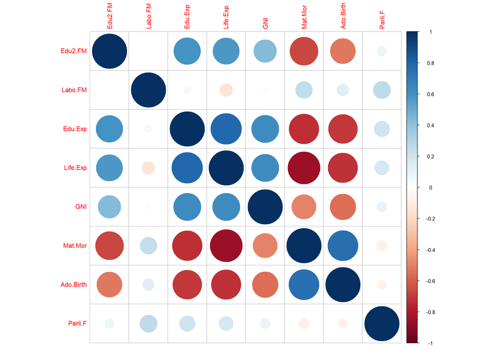

```r
#Computing the correlation matrix and visualizing it with corrplot
cor(human) %>% corrplot
```

To study the linear connections, a cor() function has been used. The output has been visualized with the corrplot function. From the corrplot we can see that:

- The **highest correlation** is between
  - *Life Expectancy at Birth* and *Expected Years of Education* (0.789)
  - *Adolescent Birth Rate* and *Maternal Mortality Ratio* (0.759)
- The **lowest (ergo negative) correlation** is between
  - *Maternal Mortality Ratio* and *Life Expectancy at Birth* (-0.857)
  - *Maternal Mortality Ratio* and *Expected Years of Education* (-0.736)
  - *Adolescent Birth Rate* and *Life Expectancy at Birth* (-0.729)

Next we will move to the PCA

## Principal Component Analysis (PCA)

Principal component analysis (PCA) is used in exploratory data analysis and for making predictive models. It is a statistical procedure that decomposes a matrix into a product of smaller matrices and then reveals the most important component.

In PCA, the data is first transformed to a new space with equal or less number of dimensions > *new features*. These new features are called the **principal components**, which always have the following properties:

- **1st** principal component captures the maximum amount of variance from the features in the original data.
- **2nd** principal component is *orthogonal* to the first and it captures the maximum amount of variability left.
- All principal components are **uncorrelated** and each is *less* important than the previous one, in terms of captured variance.

Let us perform the PCA with Singular Value Decomposition (SVD) for our *(not standardized)* data.

```r
#Performing PCA with the SVD method
pca_human <- prcomp(human)

#Creating a summary of pca_human
s <- summary(pca_human)
s
```

```
## Importance of components:
##                              PC1      PC2   PC3   PC4   PC5   PC6    PC7    PC8
## Standard deviation     1.854e+04 185.5219 25.19 11.45 3.766 1.566 0.1912 0.1591
## Proportion of Variance 9.999e-01   0.0001  0.00  0.00 0.000 0.000 0.0000 0.0000
## Cumulative Proportion  9.999e-01   1.0000  1.00  1.00 1.000 1.000 1.0000 1.0000
```

```r
#Rounded percetanges of variance captured by each PC
pca_pr <- round(100*s$importance[2, ], digits = 1)

#The percentages of variance
pca_pr
```

```
## PC1 PC2 PC3 PC4 PC5 PC6 PC7 PC8
## 100   0   0   0   0   0   0   0
```

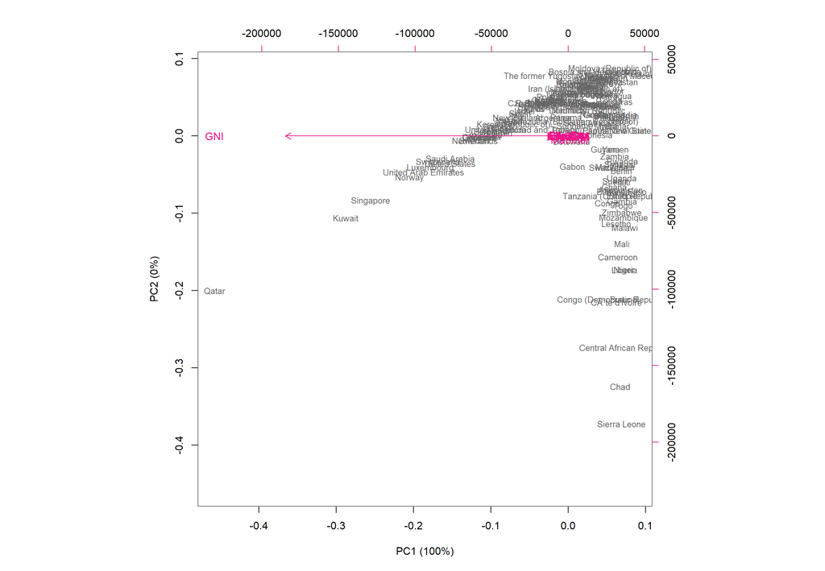

```r
#Creating object pc_lab (by the first two principal components) to be used as axis labels
pc_lab <- paste0(names(pca_pr), " (", pca_pr, "%)")

#Drawing a biplot
biplot(pca_human, cex = c(0.8, 1), col = c("grey40", "deeppink2"), xlab = pc_lab[1], ylab = pc_lab[2])
```

And now we repeat the Principal Component Analysis and its visualization for **standardized** ‘human’ data.

```r
#Standardizing the variables
human_s <- scale(human)

#Performing PCA with the SVD method
pca_human_s <- prcomp(human_s)

#Creating a summary of pca_human
s_s <- summary(pca_human_s)
s
```

```
## Importance of components:
##                              PC1      PC2   PC3   PC4   PC5   PC6    PC7    PC8
## Standard deviation     1.854e+04 185.5219 25.19 11.45 3.766 1.566 0.1912 0.1591
## Proportion of Variance 9.999e-01   0.0001  0.00  0.00 0.000 0.000 0.0000 0.0000
## Cumulative Proportion  9.999e-01   1.0000  1.00  1.00 1.000 1.000 1.0000 1.0000
```

```r
#Rounded percetanges of variance captured by each PC
pca_pr_s <- round(100*s_s$importance[2, ], digits = 1)

#The percentages of variance
pca_pr_s
```

```
##  PC1  PC2  PC3  PC4  PC5  PC6  PC7  PC8
## 53.6 16.2  9.6  7.6  5.5  3.6  2.6  1.3
```

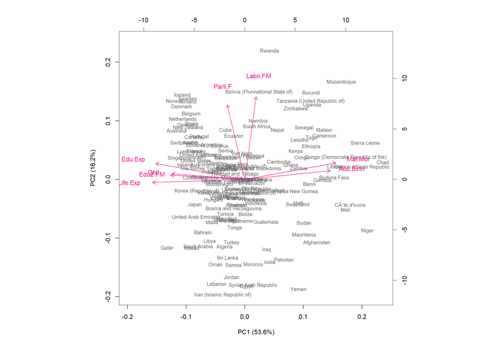

```r
#Creating object pc_lab (by the first two principal components) to be used as axis labels
pc_lab_s <- paste0(names(pca_pr_s), " (", pca_pr_s, "%)")

#Drawing a biplot
biplot(pca_human_s, cex = c(0.8, 1), col = c("grey40", "deeppink2"), xlab = pc_lab_s[1], ylab = pc_lab_s[2])
```

### Comparison between standardized and non-standardized PCA

However, as we do the rounding of variance captured by each PC notable differences occur. In case the data has *not* been standardized **all the variance is captured by the first PC (PC1)**. This makes the scaling of the biplot odd and the graph hard to look at and interpret. The Gross National Income (GNI) per Capita is overpowering all the other features and it is contributing to the dimension of PC1 (which makes sense, as all the variation has been captured by PC1).

When the data has been standardized **the variance is captured by all 8 PC’s**:

| PC1 | PC2 | PC3 | PC4 | PC5 | PC6 | PC7 | PC8 |
| --- | --- | --- | --- | --- | --- | --- | --- |
| 53.6% | 16.2% | 9.6% | 7.6% | 5.5% | 3.6% | 2.6% | 1.3% |

The points presented in the beginning of PCA-chapter apply: most of the variance is captured by the firs PC (PC1 - 53.6%) and every PC is less important than the previous one.

From the standardized graph it is easy to interpret the relation between variables:

*notes*

**1.** A scatter plot is drawn where the observations are placed on x and y coordinates defined by two first principal components PC1 (x) and PC2 (y)

**2.** Arrows are drawn to visualize the connections between the original features and the PC’s

- Angle between arrows > correlation between the features *(small angle = high positive correlation)*
- Angle between a feature and a PC axis > correlation between the two. *(small angle = high positive correlation)*
- Length of the arrow is proportional to the standard deviation of the feature

**In the standardized graph:**

- There is **positive correlation** between following features:
  - 1st batch (pointing left): *Expected Years of Education, Gross National Income (GNI) per Capita, Ratio of Female and Male populations with secondary education in each country* and *Life Expectancy at Birth*
  - 2nd batch (pointing up): *Percent Representation in Parliament* and *Ratio of labour force participation of females and males in each country*
  - 3rd batch (pointing right): *Maternal Mortality Ratio* and *Adolescent Birth Rate*
- There is **no correlation** between arrows that are orthogonal:
  - The 2nd batch (defined above) do not correlate with features from any of the other batches.
- There is **negative correlation** between arrows that are pointing to opposite directions:
  - The 1st and 3rd batches of variables correlate negatively between each other.

About the **contribution** of the principle components:

- 1st and 3rd batches of arrows are aligned with the x-axis (PC1). So these features are contributing to that dimension.
- 2nd batch of arrows is aligned with the y-axis (PC2). So these features are contributing to that dimension.

## Multiple Correspondence Analysis

For Multiple Correspondence Analysis, let us first load the ‘tea’ data set from the package ‘Factominer’. The structure of the data is explored and visualized below.

```r
library(FactoMineR)
```

```r
library(ggplot2)
library(tidyr)

#Loading the data
data("tea")

#Exploring the data set
str(tea) #300 obs. of  36 variables:
```

```
## 'data.frame':    300 obs. of  36 variables:
##  $ breakfast       : Factor w/ 2 levels "breakfast","Not.breakfast": 1 1 2 2 1 2 1 2 1 1 ...
##  $ tea.time        : Factor w/ 2 levels "Not.tea time",..: 1 1 2 1 1 1 2 2 2 1 ...
##  $ evening         : Factor w/ 2 levels "evening","Not.evening": 2 2 1 2 1 2 2 1 2 1 ...
##  $ lunch           : Factor w/ 2 levels "lunch","Not.lunch": 2 2 2 2 2 2 2 2 2 2 ...
##  $ dinner          : Factor w/ 2 levels "dinner","Not.dinner": 2 2 1 1 2 1 2 2 2 2 ...
##  $ always          : Factor w/ 2 levels "always","Not.always": 2 2 2 2 1 2 2 2 2 2 ...
##  $ home            : Factor w/ 2 levels "home","Not.home": 1 1 1 1 1 1 1 1 1 1 ...
##  $ work            : Factor w/ 2 levels "Not.work","work": 1 1 2 1 1 1 1 1 1 1 ...
##  $ tearoom         : Factor w/ 2 levels "Not.tearoom",..: 1 1 1 1 1 1 1 1 1 2 ...
##  $ friends         : Factor w/ 2 levels "friends","Not.friends": 2 2 1 2 2 2 1 2 2 2 ...
##  $ resto           : Factor w/ 2 levels "Not.resto","resto": 1 1 2 1 1 1 1 1 1 1 ...
##  $ pub             : Factor w/ 2 levels "Not.pub","pub": 1 1 1 1 1 1 1 1 1 1 ...
##  $ Tea             : Factor w/ 3 levels "black","Earl Grey",..: 1 1 2 2 2 2 2 1 2 1 ...
##  $ How             : Factor w/ 4 levels "alone","lemon",..: 1 3 1 1 1 1 1 3 3 1 ...
```

[output cut: 22 more lines]

```r
#36 variables is a lot, let us choose couple to examine closer


#Column names to keep in the data set
keep_columns <- c("Tea", "How", "how", "sugar", "where", "lunch")

#Selecting the 'keep_columns' to create a new data set
tea_time <- dplyr::select(tea, one_of(keep_columns))

#The summaries and structure of the data
summary(tea_time)
```

```
##         Tea         How                      how           sugar
##  black    : 74   alone:195   tea bag           :170   No.sugar:155
##  Earl Grey:193   lemon: 33   tea bag+unpackaged: 94   sugar   :145
##  green    : 33   milk : 63   unpackaged        : 36
##                  other:  9
##                   where           lunch
##  chain store         :192   lunch    : 44
##  chain store+tea shop: 78   Not.lunch:256
##  tea shop            : 30
##
```

```r
str(tea_time)
```

```
## 'data.frame':    300 obs. of  6 variables:
##  $ Tea  : Factor w/ 3 levels "black","Earl Grey",..: 1 1 2 2 2 2 2 1 2 1 ...
##  $ How  : Factor w/ 4 levels "alone","lemon",..: 1 3 1 1 1 1 1 3 3 1 ...
##  $ how  : Factor w/ 3 levels "tea bag","tea bag+unpackaged",..: 1 1 1 1 1 1 1 1 2 2 ...
##  $ sugar: Factor w/ 2 levels "No.sugar","sugar": 2 1 1 2 1 1 1 1 1 1 ...
##  $ where: Factor w/ 3 levels "chain store",..: 1 1 1 1 1 1 1 1 2 2 ...
##  $ lunch: Factor w/ 2 levels "lunch","Not.lunch": 2 2 2 2 2 2 2 2 2 2 ...
```

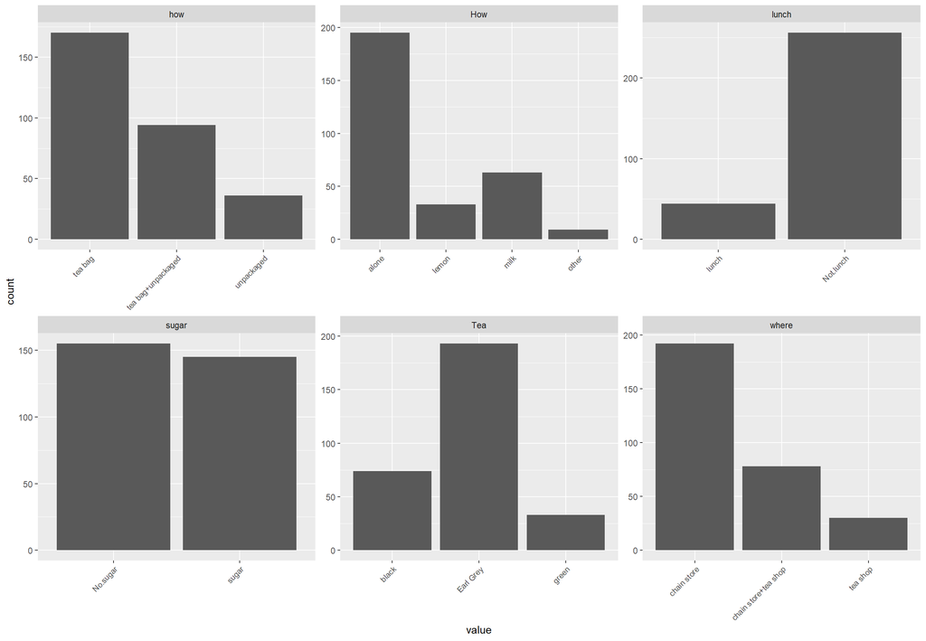

```r
#Visualization of the data set
gather(tea_time) %>% ggplot(aes(value)) + facet_wrap("key", scales = "free") + geom_bar() + theme(axis.text.x = element_text(angle = 45, hjust = 1, size = 8))
```

There is 300 observations of 36 variables. As 36 variables is quite a lot, only six of them has been taken into closer examination above: *how, How, lunch, sugar, Tea* and *where*. It seems that it is most common to drink tea alone using ready-made tea bags *(How and how)*. There is some people drinking tea during lunch time but most of the answerers drink their tea at some other point of the day *(lunch)*. It is nearly as common to drink the tea with sugar as it is not to use sugar *(sugar)*. Earl Grey is clearly most used tea type (compared to black and green tea) *(Tea)*. The tea is most likely from a chain store but also some people do buy their tea from tea shops *(where)*.

Thus, if all the results could be **concluded**: It seems that it is most common to drink Earl Grey - bought from a chain store - using ready-made tea bags and without sugar alone during some other time of the day than lunch time.

Let us do the **Multiple Correspondence Analysis (MCA)** next. MCA is a dimensionality reduction method, used to analyse the pattern of relationships of several categorical variables. MCA is a generalization of PCA. The general aim is to condense and present the information of the cross-tabulations of categorical variables in a clear graphical form.

```r
#Multiple correspondence analysis
mca <- MCA(tea_time, graph = FALSE)

#Summary of the model
summary(mca)
```

```
##
## Call:
## MCA(X = tea_time, graph = FALSE)
##
##
## Eigenvalues
##                        Dim.1   Dim.2   Dim.3   Dim.4   Dim.5   Dim.6   Dim.7
## Variance               0.279   0.261   0.219   0.189   0.177   0.156   0.144
## % of var.             15.238  14.232  11.964  10.333   9.667   8.519   7.841
## Cumulative % of var.  15.238  29.471  41.435  51.768  61.434  69.953  77.794
##                        Dim.8   Dim.9  Dim.10  Dim.11
## Variance               0.141   0.117   0.087   0.062
## % of var.              7.705   6.392   4.724   3.385
## Cumulative % of var.  85.500  91.891  96.615 100.000
##
## Individuals (the 10 first)
##                       Dim.1    ctr   cos2    Dim.2    ctr   cos2    Dim.3
## 1                  | -0.298  0.106  0.086 | -0.328  0.137  0.105 | -0.327
## 2                  | -0.237  0.067  0.036 | -0.136  0.024  0.012 | -0.695
## 3                  | -0.369  0.162  0.231 | -0.300  0.115  0.153 | -0.202
## 4                  | -0.530  0.335  0.460 | -0.318  0.129  0.166 |  0.211
## 5                  | -0.369  0.162  0.231 | -0.300  0.115  0.153 | -0.202
## 6                  | -0.369  0.162  0.231 | -0.300  0.115  0.153 | -0.202
## 7                  | -0.369  0.162  0.231 | -0.300  0.115  0.153 | -0.202
## 8                  | -0.237  0.067  0.036 | -0.136  0.024  0.012 | -0.695
## 9                  |  0.143  0.024  0.012 |  0.871  0.969  0.435 | -0.067
## 10                 |  0.476  0.271  0.140 |  0.687  0.604  0.291 | -0.650
##                       ctr   cos2
## 1                   0.163  0.104 |
## 2                   0.735  0.314 |
## 3                   0.062  0.069 |
## 4                   0.068  0.073 |
## 5                   0.062  0.069 |
## 6                   0.062  0.069 |
## 7                   0.062  0.069 |
## 8                   0.735  0.314 |
## 9                   0.007  0.003 |
## 10                  0.643  0.261 |
##
## Categories (the 10 first)
```

[output cut: 16 more lines]

```
## lemon                3.226 |   1.329  14.771   0.218   8.081 |
## milk                 2.422 |   0.013   0.003   0.000   0.116 |
## other                5.534 |  -2.524  14.526   0.197  -7.676 |
## tea bag             -6.941 |  -0.065   0.183   0.006  -1.287 |
## tea bag+unpackaged  11.956 |   0.019   0.009   0.000   0.226 |
## unpackaged          -6.482 |   0.257   0.602   0.009   1.640 |
##
## Categorical variables (eta2)
##                      Dim.1 Dim.2 Dim.3
## Tea                | 0.126 0.108 0.410 |
## How                | 0.076 0.190 0.394 |
## how                | 0.708 0.522 0.010 |
## sugar              | 0.065 0.001 0.336 |
## where              | 0.702 0.681 0.055 |
## lunch              | 0.000 0.064 0.111 |
```

In the summary of MCA we have first the **Eigenvalues**. There we can see the variances and the percentage of variances retained by each (11) dimension.

Then we have **Individuals**. Here we have the 10 first individuals coordinates, individuals contribution (%) on the dimension and the cos2 (the squared correlations) on the dimensions.

Lastly we have **Categorical variables**. There we have the squared correlation between each variable and the dimensions. Values close to 1 indicate a strong link with the variable and dimension. See *how* and *Dim.1* (0.708); *where* and *Dim.1* (0.702).

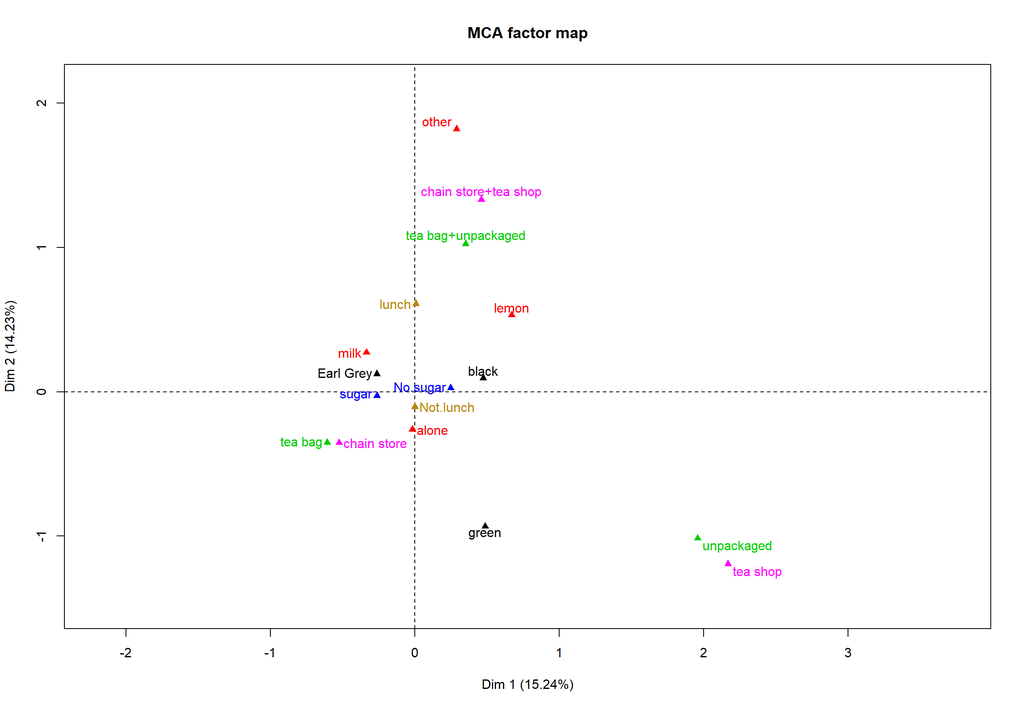

```r
#Visualization of MCA
plot(mca, invisible=c("ind"), habillage = "quali", graph.type = "classic")
```

Here we have MCA factor map as biplot. The variables have been drawn on the first two dimensions (Dim 1 explaining ~15% and Dim 2 ~14%). The distance between variable categories giver a measure of their similarity *(the more close the more similar)*.

- The following are **similar** together:
  - *milk, Earl Grey* and *sugar*
  - *tea bag* and *chain store*
  - *Not lunch* and *alone*
  - *unpackaged* and *tea shop*
- The following **differ** from all the others:
  - *other*
  - *lemon*
  - *green*
  - *unpackaged* and *tea shop* > similar together but differ from all the others

> *Summary of my learning*

This week I got answers to some of the questions I had last week. The explanations how to interpret biplots were especially important and interesting. I think everything went well this week and therefore I am feeling quite exited!

Regards, *Janina*